# Microsimulación espacial del empleo formal en el Gran Santiago y su relación con el hacinamiento y la población migrante

Nicolás Santibáñez

2025-10-30

# 1. Introducción

En la Región Metropolitana se ha dado *un contexto de creciente urbanización e incremento de pobreza, se suman otras problemáticas presentes en barrios, ciudades y localidades, tales como: la segregación espacial, la concentración de la pobreza, la fragmentación, la inseguridad, el hacinamiento, la baja conextividad, los problemas de localización y la falta de acceso equitativo a bienes públicos urbanos **(PNUD,2022; MINVU, 2023)***. El **Censo 2017** permite analizar estás diferencias a escala censal, ofreciendo así una herramienta solida para identificar patrones de concentración y segregación *(INE, 2018)*.

La presente entrega se desarrolla en continuidad con la **Entrega 1** del presente curso, en donde a partir de los porcentajes por zona censal se indentificaron patrones de concentración en la población migrante y altos niveles de hacinamiento en sectores del centro y del poniente. En esta segunda parte se incorpora la variable de empleo formal a partir del procesamiento de una variable de la **CASEN**, para poder relacionarla con estas zonas de la **Entrega 1** previamente mencionadas.

Desde el enfoque del presente curso de **Geomakerting/Inteligencia de datos Geoespaciales**, se utilizaran mapas bivariados dado que permite representar simultaneamente dos variables, para así tener una visión que unifique ambas tendencias para identificar zonas de desigualdades urbanas, pudiendo así aportar herramientas para la planificación y toma de decisiones.

## 1.1 Objetivo General

**Aplicar metodología de Microsimulación Espacial mediante el paquete `rakeR`, utilizando la variable de empleo formal obtenida desde la CASEN 2022, con el fin de desagregarla a nivel de zona censal dentro del Gran Santiago y analizar su relación espacial con los indicadores de migración y hacinamiento provenientes del Censo 2017.**

## 1.2 Objetivos específicos

1. **Procesar y preparar los datos de CASEN 2022** para poder obtener la variable empleo formal, además de asegurar su compatibilidad con la estructura del Censo 2017
2. **Aplicar la metodología de microsimulación espacial** a través del paquete `rakeR`, con el propósito de desagregar la información del empleo formal a nivel de zona censal en el Gran Santiago.
3. **Integrar los resultados de la microsimulación con los indicadores de migración y hacinamiento** provenientes del Censo 2017.
4. **Generar mapas** que permitan visualizar la relación espacial entre las tres variables seleccionadas y los patrones de desigualdad urbana resultantes.
5. **Analizar e interpretar los patrones espaciales identificados**, buscando posibles explicaciónes a causas y la relevancia de la información obtenida para la planificación territorial y para la toma de decisiones.

# 2. Metodología

La metodología de este trabajo combina el uso de datos censales y de encuesta para poder generar información desagregada a nivel de zona censal en en área del Gran Santiago. Para realizar esto utilizó microsimulación espacial, la cual permite estimar variables de encuesta en unidades geoggráficas menores a través del ajuste de distribuciones de población.

En particular se utilizaró el paquete `rakeR` de R, este paquete implemente el método de ajuste iterativo de proporciones. Este procedimiento calibra los datos de la **Encuesta CASEN 2022** a partir de las frecuencias observadas en el **Censo 2017**, para obtener así una estimación coherente de la variable de empleo formal a nivel de zona censal.

## 2.1 Proceso Metodológico

-Procesamiento de CASEN, selección de variable de empleo formal

-Aplicación del modelo de microsimulación espacial

-Integración de resultados con indicadores censales de migración y hacinamiento obtenidos en la Entrega 1

-Generación de mapas para analizar la relación espacial de las variables y su distribución

A continuación se detallan las caracteristicas de las variables utilizadas, las fórmulas para su cálculo y el procedimiento para su procesamiento y visualización.

## 2.2 Implementación en R

### 2.2.1 Librerias utilizadas

Para el desarrollo del trabajo se utilizaron las siguientes librerias orientadas a la manipulación, simulación y visualización de datos espaciales.

```r
library(rakeR)       # Microsimulación espacial (raking)
library(RPostgres)   # Conexión con base de datos PostgreSQL
library(DBI)         # Interfaz para manejo de bases de datos
library(sf)          # Manejo de datos espaciales (objetos simple features)
library(dplyr)       # Manipulación de datos tabulares
library(data.table)  # Procesamiento eficiente de grandes volúmenes de datos
library(tmap)        # Cartografía temática
library(biscale)     # Construcción de mapas bivariados
library(ggplot2)     # Visualización gráfica
library(patchwork)   # Composición de múltiples gráficos
library(ggrepel)     # Etiquetado inteligente de textos en ggplot
```

### 2.2.2 Entradas de datos

En este bloque del codigo se definieron las rutasde acceso a los archivos de bases de datos de la Encuesta **CASEN 2022** y del **Censo 2017** en formato `.rds` para su lectura en R.

La base de **Casen 2022** aportará la caracterización socieconomica, mientras que la base del **Censo 2017** entregará información agregada por zona censal, la cual es necesaria para la calibración posterior de variables.

Además se cargo base de indicadores correspondiente a las variables a utilizar de hacinamiento y migración de la Entrega 1.

```r
ruta_casen = "Data/casen_rm.rds"
ruta_censo = "Data/cons_censo_df.rds"
ruta_indicadores = "Data/df_indicadores.rds"

casen_raw = readRDS(ruta_casen)
cons_censo_df = readRDS(ruta_censo)
df_indicadores = readRDS(ruta_indicadores) #Proveniente de Entrega 1
```

### 2.2.3 Preprocesamiento

El preprocesamiento tuvo como objetivo armonizar la base de **CASEN 2O22 con el Censo 2017**, generando así variables comparables y estructurando adecuadamente para poder aplicar el modelo de microsimulación espacial.

El primer paso es seleccionar las variables de ambas bases y definir las categorías utilizadas como variables de control dentro del modelo (edad, escolaridad y sexo). Posterior a ello se generó la variable binaria de formalidad laboral.

### 2.2.4 Microsimulación

La microsimulación se aplicó con objetivo de ajustar la estructura de las bases utilizadas, esto a modo de estimar la proporción de empleo formal a nivel de zona censal dentro del Gran Santiago.

Este procedimiento fue de forma iterativa por comuna, por lo que se fue ajustando las variables de control mediante el método de ranking implementado en `rakeR`.

- Separación de bases por comuna
- Ejecución de modelo de microsimulación
- Consolidación de resultados y cálculo por zona censal

  ```r
  # Unir todos los resultados en un solo data frame
  sim_df = data.table::rbindlist(sim_list, idcol = "COMUNA")

  # --- Agregación por zona censal: FORMALIDAD LABORAL ---
  zonas_formal = aggregate(
    o12_formal ~ zone,
    data = sim_df,
    FUN = function(x) mean(x, na.rm = TRUE)
  )
  names(zonas_formal) <- c("geocodigo", "prop_trabajo_formal")
  ```

### 2.2.5 Conexión a base de datos y unión final

Una vez se generán las estimaciones de formalidad laboral, se establece una conexión con la base de datos generada en la Entrega 1 de **PostgreSQL** que contiene la información geoespacial del **Censo 2017 en la Región Metropolitana.**

Luego se procede a guardar la tabla con los resultados de microsimulación en el esquema **Output** de la base de datos del servidor.

Además se agrego una sección para la lectura de zonas censales urbanas correspondientes al Gran Santiago. Esta consulta corresponde a un filtro SQL para solo considerar las comunas correspondientes, además de guardar las comunas con sus nombres aparte:

```r
# Leer zonas censales del Gran Santiago
query_gs = "
SELECT *
FROM dpa.zonas_censales_rm
WHERE urbano = 1
AND nom_comuna IN (
  'SANTIAGO','INDEPENDENCIA','RECOLETA','CONCHALÍ','HUECHURABA',
  'VITACURA','LAS CONDES','LO BARNECHEA','PROVIDENCIA','ÑUÑOA',
  'MACUL','PEÑALOLÉN','LA REINA','LA FLORIDA','PUENTE ALTO',
  'LA GRANJA','SAN RAMÓN','LA PINTANA','EL BOSQUE','SAN BERNARDO',
  'CERRILLOS','CERRO NAVIA','LO PRADO','QUINTA NORMAL',
  'ESTACIÓN CENTRAL','PEDRO AGUIRRE CERDA','SAN MIGUEL','LO ESPEJO',
  'MAIPÚ','SAN JOAQUÍN','LA CISTERNA','PUDAHUEL','RENCA','QUILICURA',
  'LO BARNECHEA','PROVIDENCIA','VITACURA'
);
"
sql_comunas = "
SELECT nom_comuna, geom
FROM dpa.comunas_rm_shp;
"

sf_comunas = st_read(con, query = sql_comunas)
zonas_gs = st_read(con, query = query_gs)
```

Finalmente se estandarizaron los indicadores de la zona (`geocodigo`) para asegurar que haya compatibilidad entre todas las tablas, posterior a ello se realizó la unión final de todas las variables en el objeto espacial `zonas_gs_final`

## Variables e indicadores

En esta sección se describen las variables utilizadas en el análisis, como se obtuvieron, su forma de calcular y el tratamiento previo a la generación de los mapas. Cada una de ellas representa una distinta forma de observar las diferencias urbanas en este caso a nivel laboral, demográfico y habitacional.

### 2.2.7.Empleo formal (CASEN 2022)

La variable de empleo formal se construyo a partir de la encuesta **CASEN 2022**, utilizando el módulo de ocupación laboral. Dado que los valores de la encuesta diferenciaban categorías según la condición de ocupación se realizó un proceso de **recategorización binaria**, asignando el valor 1 a las personas con empleo formal y 0 a quienes se encontraban en situación de empleo imformal

### 2.2.8 Población migrante (Censo 2017)

Esta variable corresponde a el porcentaje de habitantes nacidos en el extranjkero respecto al total de la población en cada zona censal. A partir de este indicador es posible aproximar la composición a nivel demográfico de cada zona censal y evidenciar sectores de mayor concentración.

$\text{Porcentaje de Migrantes} = \frac{\text{Personas migrantes}}{\text{Total de personas}} \times 100$

Este indicador se obtuvo a través de los datos del **Censo 2017**, procesados a nivel de zona censal y empleado para la comparación en el análisis bivariado.

### 2.2.9 Hacinamiento

La tercera variable a utilizar corresponde al porcentaje de viviendas con más de dos personas por dormitorio dentro de cada zona censal. Este indicador nos permite aproximar condiciones de vulnerabilidad habitacional y de la alta densidad poblacional en determinados sectores urbanos.

$\text{Porcentaje de hacinamiento} = \frac{\text{Viviendas con más de dos personas por dormitorio}}{\text{Total de viviendasas}} \times 100$

Este calculo se realizo a través de la información en el modulo de Vivienda del Censo 2017, en donde se consideraron únicamente viviendas particularmente ocupadas.

### 2.3.6 Generación de mapas

Habiendo generado la base espacial final, se procedió a elaborar los mapas para representar la distribución territorial de las variables analizadas. Dicha visualización se realizo en las librerías `tmap`, `ggplot2` y `biscale`, las cuales permitieron representar las dimensiones de estas variables.

Primero se definió la ruta de salida de los mapas y se generaron centroides para cada comuna para las etiquetas en los mapas.

**Mapa 1: Distribución de la ponderación de empleo formal en el Gran Santiago**

Bloque de generación de Mapa 1 que muestra la distribución en el Gran Santiago a través del uso de la libreria `tmap`.

```r
# --- Mapa 1: Empleo formal ---
map_formal <- tm_shape(zonas_gs_final) +
  tm_polygons(
    fill = "prop_trabajo_formal",
    fill.scale = tm_scale_intervals(style = "quantile", n = 5, values = "Blues"),
    fill.legend = tm_legend(title = "Proporción empleo formal")
  ) +

  # Límites comunales
  tm_shape(sf_comunas_gs) +
  tm_borders(col = "black", lwd = 2) +

  # Fondo blanco (rectángulo)
  tm_shape(centroides_comunas) +
  tm_symbols(
    size = 0.08,            # tamaño del rectángulo
    shape = 22,             # cuadrado relleno
    col = "white",          # color del fondo
    border.col = "grey30",  # contorno del fondo
    border.lwd = 0.3
  ) +

  # Texto encima del rectángulo
  tm_shape(centroides_comunas) +
  tm_text(
    text = "nom_comuna",
    size = 0.5,
    col = "black",
    just = "center",
    auto.placement = TRUE
  ) +

  tm_title("Empleo formal en el Gran Santiago (Microsimulación)") +
  tm_legend(outside = TRUE)

# Guardar el mapa
tmap_save(
  map_formal,
  file.path(ruta_salida, "mapa_formalidad_gran_santiago.png"),
  dpi = 300
)
```

**Mapa 2: Mapa Bivariado de formalidad y hacinamiento**

Bloque de generación del Mapa 2 bivariado generado utilizando las librerias `biscale` y `ggplot2`.

```r
# --- Crear variable bivariada ---
biv_formal_hac <- bi_class(
  zonas_gs_final |> dplyr::filter(!is.na(prop_trabajo_formal), !is.na(ptje_hacinamiento)),
  x = prop_trabajo_formal,
  y = ptje_hacinamiento,
  style = "quantile",
  dim = 3
)
# --- 3. Crear mapa ---
map_bivar_formal_hac <- ggplot() +
  geom_sf(data = biv_formal_hac, aes(fill = bi_class), color = "white", size = 0.1) +
  bi_scale_fill(pal = "DkViolet", dim = 3) +
  geom_label_repel(
    data = centroides_comunas,
    aes(X, Y, label = nom_comuna),
    size = 2.3, color = "black",
    fill = "white", label.size = 0.2,
    label.padding = unit(0.12, "lines"),
    max.overlaps = Inf
  ) +
  bi_theme() +
  labs(
    title = "Formalidad laboral y Hacinamiento en el Gran Santiago",
    subtitle = "Microsimulación CASEN 2022 + CENSO 2017",
    caption = "Elaboración propia con datos CASEN (2022) y CENSO (2017)"
  ) +
  theme_void() +
  theme(
    plot.background = element_rect(fill = "grey98", color = NA),
    plot.title = element_text(size = 15, face = "bold", hjust = 0.5),
    plot.subtitle = element_text(size = 11, hjust = 0.5, margin = margin(b = 10)),
    plot.caption = element_text(size = 9, color = "grey40", hjust = 1)
  )

# --- Leyenda bivariada ---
legend_bivar <- bi_legend(
  pal = "DkViolet",
  dim = 3,
  xlab = "→ Mayor formalidad laboral",
  ylab = "↑ Mayor hacinamiento",
  size = 6
)

# --- Combinar mapa y leyenda ---
library(cowplot)
final_bivar_formal_hac <- ggdraw() +
  draw_plot(map_bivar_formal_hac, 0, 0, 1, 1) +
  draw_plot(legend_bivar, 0.73, 0.07, 0.25, 0.25)

# ---Exportar ---
ggsave(
  filename = file.path(ruta_salida, "mapa_bivariado_formalidad_hacinamiento.png"),
  plot = final_bivar_formal_hac,
  width = 10, height = 8, dpi = 300
)
cat("✅ Mapa bivariado: Formalidad laboral vs Hacinamiento generado correctamente\n")
```

**Mapa 3: Mapa bivariado de formalidad laboral y migración**

Bloque de generación de Mapa 3 bivariado generado utilizando las librerias `biscale` y `ggplot2`.

```r
# Crear variable bivariada
biv_formal_extranj <- bi_class(
  zonas_gs_final |> dplyr::filter(!is.na(prop_trabajo_formal), !is.na(ptje_extranjeros)),
  x = prop_trabajo_formal,
  y = ptje_extranjeros,
  style = "quantile",
  dim = 3
)
# ---Crear mapa bivariado ---
map_bivar_formal_extranj <- ggplot() +
  geom_sf(data = biv_formal_extranj, aes(fill = bi_class), color = "white", size = 0.1) +
  bi_scale_fill(pal = "DkCyan", dim = 3) +  # paleta diferente para distinguirlo del mapa 2
  geom_label_repel(
    data = centroides_comunas,
    aes(X, Y, label = nom_comuna),
    size = 2.3,
    color = "black",
    fill = "white",
    label.size = 0.2,
    label.padding = unit(0.12, "lines"),
    max.overlaps = Inf
  ) +
  bi_theme() +
  labs(
    title = "Formalidad laboral y Población extranjera en el Gran Santiago",
    subtitle = "Microsimulación CASEN 2022 + CENSO 2017",
    caption = "Elaboración propia con datos CASEN (2022) y CENSO (2017)"
  ) +
  theme_void() +
  theme(
    plot.background = element_rect(fill = "grey98", color = NA),
    plot.title = element_text(size = 15, face = "bold", hjust = 0.5),
    plot.subtitle = element_text(size = 11, hjust = 0.5, margin = margin(b = 10)),
    plot.caption = element_text(size = 9, color = "grey40", hjust = 1)
  )

# --- Leyenda bivariada ---
legend_bivar_extranj <- bi_legend(
  pal = "DkCyan",
  dim = 3,
  xlab = "→ Mayor formalidad laboral",
  ylab = "↑ Mayor población extranjera",
  size = 6
)

# --- Combinar mapa y leyenda ---
final_bivar_formal_extranj <- ggdraw() +
  draw_plot(map_bivar_formal_extranj, 0, 0, 1, 1) +
  draw_plot(legend_bivar_extranj, 0.73, 0.07, 0.25, 0.25)

# --- Exportar ---
ggsave(
  filename = file.path(ruta_salida, "mapa_bivariado_formalidad_extranjeros.png"),
  plot = final_bivar_formal_extranj,
  width = 10, height = 8, dpi = 300
)
cat("✅ Mapa 3: 'mapa_bivariado_formalidad_extranjeros.png' generado correctamente\n")
```

# 3. Resultados

En estta sección se presentan los resultados obtenidos a través del proceso de microsimulación espacial. Esta representación corresponde a mapas elaborados para observar la districión territorial de las variables, así como la relación entre estas en el Gran Santiago

## 3.1 Mapa 1 Empleo formal

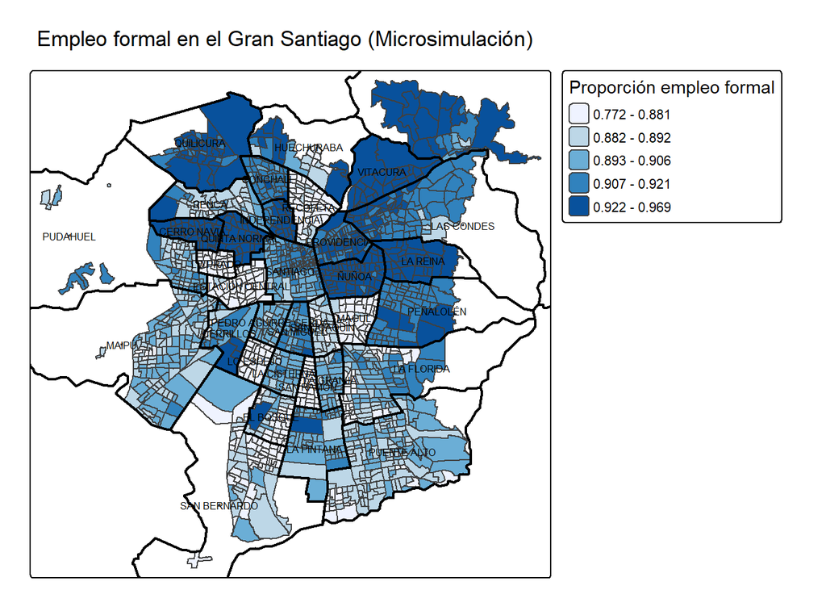

## 3.2 Mapa 2 Bivariado Empleo formal y Hacinamiento

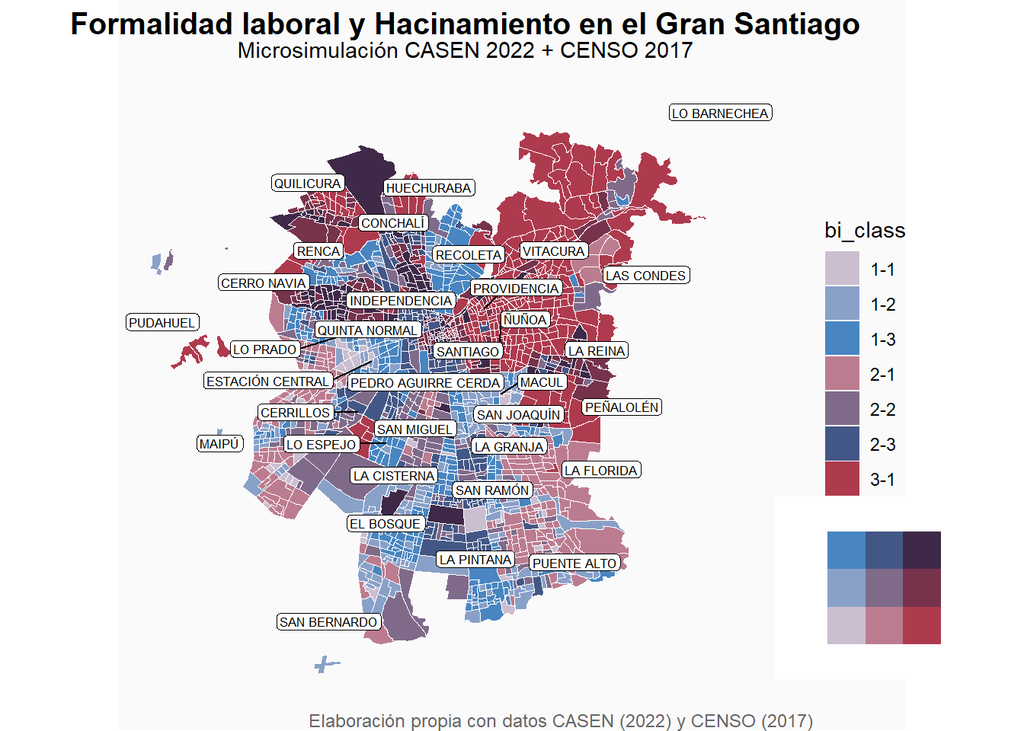

## 3.3 Mapa 3 Bivariado Empleo formal y Migración

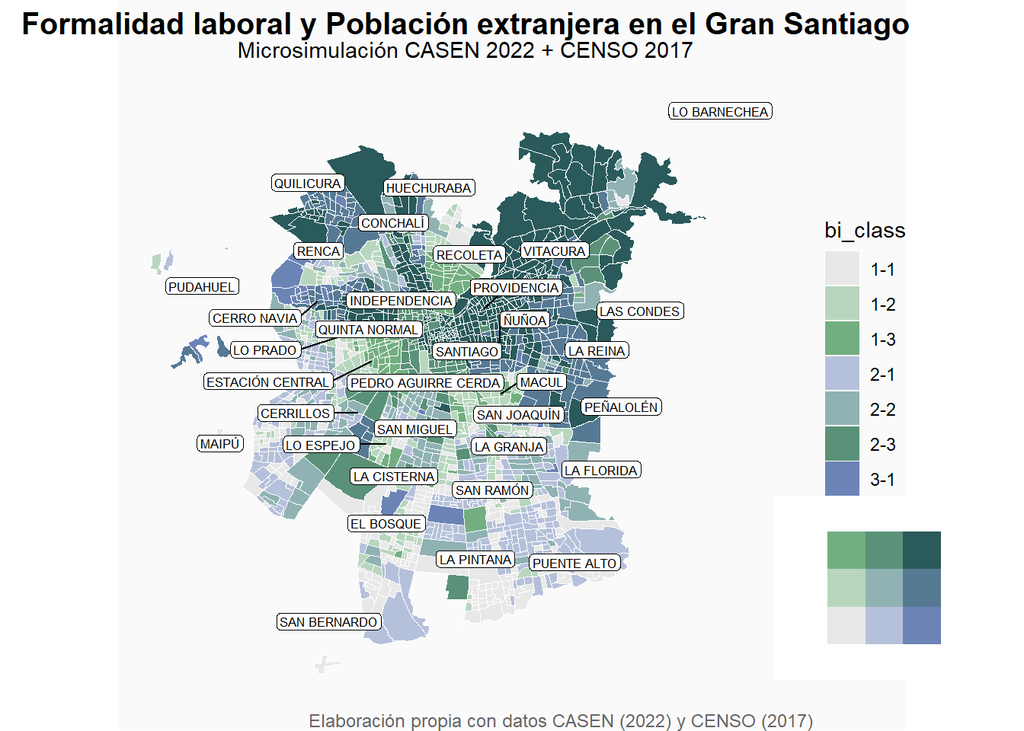

En este caso el patrón sugiere que los sectores del centro y poniente presentan alta presencia migrante y bajos niveles de formalidad respecto a la totalidad del territorio. Por lo contrario se observan valores de alta formalidad en comunas del oriente mostrando tambien presencia de migrantes en algunas zonas.

# 4. Análisis espacial

El análisis espacial de los resultados permitira comprender la manera en que se distribuyen las condiciones laborales en el Gran Santiago y así mismo su relación con las otras variables habitacionales y demográficas.

Al aplicar el modelo de microsimulación espacial se pudo estimar la proporción de empleo formal en zona censal, lo que junto con los indicadores de hacinamiento y población migrante revela una marcada desigualdad territorial en la estructura del Gran Santiago

## 4.1 Empleo formal

Este patrón puede reflejar la fuerte segregación económica que se presenta en el área metropólitana, en dónde el factor de la formalidad laboral se asocia con mayor educación, mayores ingresos y presencia de sectores productivos de alta calificación (*PNUD, 2022: MINVU, 2023).* A su contraste las zonas con menor formalidad coinciden en general con áreas de menor conectividad y mayor pobreza, en dónde predominan empleos precarios o informales *(OIT, 2021).*

## 4.2 Relación entre empleo formal y hacinamiento

Desde la perspectiva de la planificación, este análisis nos permite identificar territorios críticos en dónde las políticas de vivienda y empleo podrían tener un mayor impacto

## 4.3 Relación entre empleo formal y población migrante

Este segundo mapa bivariado cruza la formalidad laboral con el porcentaje de población migrante, evidenciando una dsitribución distinta a las anteriores pero al mismo tiempo desigual.

Este patrón indica una segmentación del mercado laoral, en dónde la población migrante se encuentra en gran parte inserta en sector de trabajo informal y precario, muchas veces asociados al comercio, servicios domesticos o construcción *(INE,2018; PNUD, 2022).*

Este fenómeno se concentra principalmente en comunas como **Estación Central, Recoleta, Independencia y Santiago centro**. Esta situación sugiere la necesidad de políticas migratorias y de inserción laboral, además de regularización habitacional.

# 5. Conclusiones

Este trabajo permitió aplicar la metodología propuesta de **Microsimulación espacial** mediante la libreria `rakeR`, utilizando la variable del empleo formal obtenida desde la Encuesta **CASEN 2022** y ajustando esta a las distribuciones del Censo 2017 en el Gran Santiago. Esto permitió desagregar la información de la encuesta a nivel de **zona censal**, generando una aproximación detallada de la distribución en el territorio.

Los análisis bivariados permitieron profundizar entre las relaciones de las variables de la **Entrega 1 (hacinamiento y migración)** con la formalidad laboral. La población migrante evidenció desigualdad en el mercado laboral, reflejandose mayor presencia de estos en comunas con **mayor empleo informal y condiciones habitacionales precarias.**

Estos hallazgos evidencian las desigualdades en diferentes dimensiones y como estás se distribuyen en el Gran Santiago. La microsimulación se presenta a su vez como una herramienta útil para el enfoque de **Inteligencia en Datos Geoespaciales,** pues permiteg generar información procesada para su uso en planificación y toma de decisiones.

Finalmente el uso de mapas bivariados demostró al igual que en la primera entrega el ser una herramienta valiosa para visualizar la relación y superposición de problematicas urbanas, facilitando así la identificación de **zonas críticas** y pudiendo así priorizar zonas en post de reducir las brechas sociales en nuestra ciudad.

# 6. Bibliografía

Instituto Nacional de Estadísticas (INE). (2018). *Síntesis de resultados Censo 2017*. Gobierno de Chile.  
https://www.censo2017.cl

Ministerio de Vivienda y Urbanismo (MINVU). (2023). *Observatorio Urbano: Indicadores comunales Región Metropolitana*. Gobierno de Chile.  
https://www.observatoriourbano.cl

Organización Internacional del Trabajo (OIT). (2021). *Panorama laboral de América Latina y el Caribe 2021*. Oficina Regional de la OIT para América Latina y el Caribe.  
https://www.ilo.org

Programa de las Naciones Unidas para el Desarrollo (PNUD). (2022). *Informe sobre Desarrollo Humano en Chile: Desiguales. Orígenes, cambios y desafíos*. Santiago de Chile: PNUD Chile.  
https://www.cl.undp.org

Ministerio de Desarrollo Social y Familia (MDSF). (2022). *Encuesta de Caracterización Socioeconómica Nacional (CASEN) 2022*. Gobierno de Chile. https://observatorio.ministeriodesarrollosocial.gob.cl/encuesta-casen